# Анализ продаж розничных магазинов

Tikhon Mukha

26 04 2020

## Постановка задачи

Есть массив данных с информацией о продажах розничных магазинов за два временных периода, собранный в один датасет.

Датасет содержит 31992 записи о продажах от 6 магазинов. Этими магазинами являются: AUCHAN ZORYANYJ, AUCHAN.UA-MAG, FROUNZE, LEPSE, PRAVDY, WILLIAMSA.

Всего в датасете 21 столбец: Название уровня номенклатуры, Артикул, Категория, Производитель, Бренд, Наименование, Вес, Формат упаковки, Наименование, Основной поставщик, Статус артикула в GICA, Артикул удален в GICA, Тип товара, Единица товара, Количество товаров (шт.), Количество товаров (л./кг.), Товарооборот с НДС (грн.), Тариф закупки (грн.), Маржа FIFO, Магазин, Период

С использованием предоставленных данных нужно подготовить отчет по:

1. анализу продаж по категориям;
2. анализу продаж по временным периодам;
3. анализу продаж по магазинам;
4. анализу продаж товарных категорий “Пельмени” и “Вареники”.

## Преобразование данных

Датасет содержит некоторые проблемные места, такие как незаполненные столбцы, неверно определнные типы данных, содержание в записях лишних символов (пробелы, звездочки). Поэтому перед началом работы нужно провести ряд преобразований, которые повысят удобство обрабоки данных:

- убираем лишний столбец “Наименование”. В датасете два столбца с таким названием, при этом в одном из них перечислены SKU (stock keeping units), а другой столбец - пустой, его и нужно удалить;
- преобразуем столбцы, содержащие уникальный id поставщика товара и артикул товара, из целочисленных переменных в факторные. Это необходимо для корректной работы с данными;
- оставшийся столбец Наименование содержит в названиях некоторых SKU лишние символы: звездочки (*) и пробелы. За счет этого группировка данных по SKU может быть выполнена некорректно, так как, например, SKU с названиями “лосось соленый” и “лосось * соленый” будут восприниматься как разные группы, поэтому данные символы нужно удалить из всех записей этого столбца;
- также все записи по магазину “AUCHAN.UA-MAG” следует удалить, так как никакой информации о продажах по этому магазину не предоставлено;
- добавим новые столбцы: “Доля рынка” = Товарооборот единицы / Общий товарооборот, “Товарные запасы” = Количество товаров * Тариф закупки;
- переименуем некоторые столбцы для удобства обращения к ним.

Подобные проблемы достаточно часто возникают при выгрузке файлов из различных баз данных.

После всех преобразований мы получаем пригодный к работе датасет,

```
## # A tibble: 26,660 x 22
##    Номенклатура Артикул Категория Производитель Бренд   Вес Упаковка
##    <fct>        <fct>   <fct>     <fct>         <fct> <int> <fct>
##  1 ТЕРМОПАКЕТИ  535431  ""        ""            ""       NA ""
##  2 ТЕРМОПАКЕТИ  469887  ""        ""            ""       NA ""
##  3 ТЕРМОПАКЕТИ  116358  ""        ""            ""       NA ""
##  4 ЗАМОРОЖЕНІ ~ 598353  ""        ""            ""       NA ""
##  5 ЗАМОРОЖЕНІ ~ 527270  ""        ""            ""       NA ""
##  6 ЗАМОРОЖЕНІ ~ 527269  ""        ""            ""       NA ""
##  7 ЗАМОРОЖЕНІ ~ 527267  ""        ""            ""       NA ""
##  8 ЗАМОРОЖЕНІ ~ 527247  ""        ""            ""       NA ""
##  9 ЗАМОРОЖЕНІ ~ 518001  ""        ""            ""       NA ""
## 10 ЗАМОРОЖЕНІ ~ 451317  ""        ""            ""       NA ""
## # ... with 26,650 more rows, and 15 more variables: Наименование <fct>,
## #   Поставщик <fct>, `Артикул GICA` <fct>, `Артикул удален в GICA` <lgl>, `Тип
## #   товара` <fct>, `Единица товара` <fct>, `Количество товаров (шт.)` <int>,
## #   `Количество товаров (л./кг.)` <dbl>, `Товарооборот с НДС (грн.)` <dbl>,
## #   `Тариф закупки (грн.)` <dbl>, `Маржа FIFO` <dbl>, Магазин <fct>,
## #   Период <fct>, Доля_рынка <dbl>, Товарные_запасы <dbl>
```

который содержит 22 столбца с 26660 записями.

## Анализ данных

### 1. Анализ продаж по категориям

Датасет содержит 113 товарных категорий. Анализировать такое большое количество категорий довольно трудно и не имеет особого смысла, поэтому для анализа будут определяться 10 ведущих категорий по определенному показателю.

Сперва следует оценить категории по товарообороту:

Категории с наибольшим товарооборотом

[output not shown]

[figure not shown]

Среди 10 категорий с наибольшим товарооборотом выделяется “Рыба речная”, опережающая ближайшего преследователя “Лосось соленый кусковой” более чем в 2 раза. Можно, предположить, что данная категория пользуется наибольшим спросом у потребителей. Однако для точной оценки следует знать также и количество произведенных продаж.

При оценке категорий по количеству продаж

Наиболее продаваемые категории

| Номенклатура | Количество_продаж | Товарооборот_млн_грн | Доля_рынка | Средняя_маржа_% |
| --- | --- | --- | --- | --- |
| МОР-ВО БАТОНЧИК Д/ДОРОСЛ | 1300 | 1780.54 | 5.07 | 17.30 |
| РИБА ХОЛОДНОГО КОПЧЕННЯ | 1100 | 862.76 | 2.46 | 7.95 |
| РИБА В`ЯЛЕНА/СУШЕН ПРИЛ-К | 1010 | 530.61 | 1.51 | 21.06 |
| ПЕЛЬМЕНІ | 880 | 1137.58 | 3.24 | 16.10 |
| ІКРА ЧОРНА ТА ЧЕРВОНА | 870 | 1542.14 | 4.39 | 9.84 |
| СТАКАНЧИКИ | 870 | 1167.84 | 3.33 | 16.19 |
| ІКРА ІНША | 860 | 941.25 | 2.68 | 17.56 |
| РІЖОК | 830 | 1012.25 | 2.88 | 14.85 |
| РИБ МОРСЬК ЗАМОР ТУШК ВАГ | 730 | 1464.59 | 4.17 | 9.11 |
| РІЧКОВА РИБА | 710 | 4053.05 | 11.54 | 39.03 |

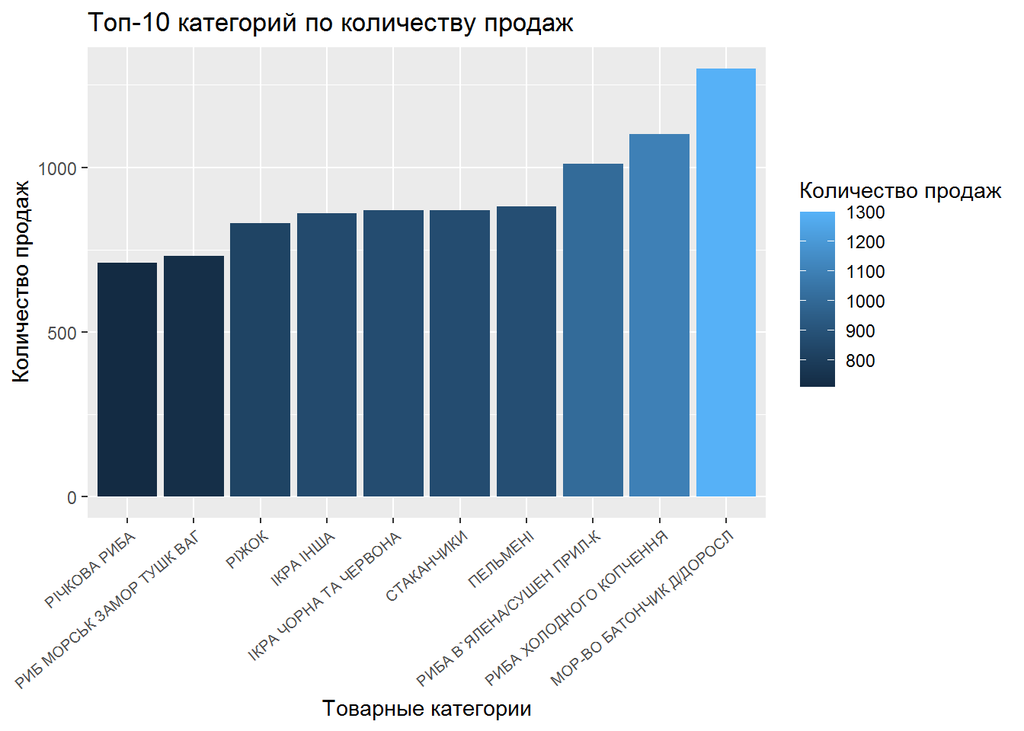

становится очевидно, что, хотя “Рыба речная” и входит в топ-10 по этому показателю, категория находится на последнем месте, уступая лидеру - “Мороженое батончик для взрослых” практически в 2 раза. При этом разрыв между топами по показателю количества продаж не такой большой, как по товарообороту, из чего можно сделать вывод о том, что лидерство категорий по товарообороту обеспечивается не столько за счет количества продаж, сколько за счет их маржинальности:

Наиболее маржинальные категории

| Номенклатура | Средняя_маржа_% | Количество_продаж | Товарооборот_млн_грн | Доля_рынка |
| --- | --- | --- | --- | --- |
| РИБА СОЛОНА Ф/М | 83.31 | 90 | 1.60 | 0.00 |
| УПАКОВКА | 83.12 | 90 | 1.53 | 0.00 |
| ЛОСОСЬ | 61.80 | 130 | 588.43 | 1.68 |
| РИБА СТЕЙКИ ПРИЛАВОК | 54.14 | 280 | 1872.64 | 5.33 |
| РИБНІ НАПІВФАБР ПРИЛАВОК | 51.99 | 510 | 851.97 | 2.43 |
| РИБА ТУШКИ ПРИЛАВОК | 50.84 | 230 | 267.11 | 0.76 |
| РИБА ЖИВА | 48.82 | 130 | 50.41 | 0.14 |
| ЛОСОСЬ Ф/М | 44.66 | 130 | 26.44 | 0.08 |
| РІЧКОВА РИБА | 39.03 | 710 | 4053.05 | 11.54 |
| РИБА ЧИЩЕНА | 34.46 | 120 | 44.01 | 0.13 |

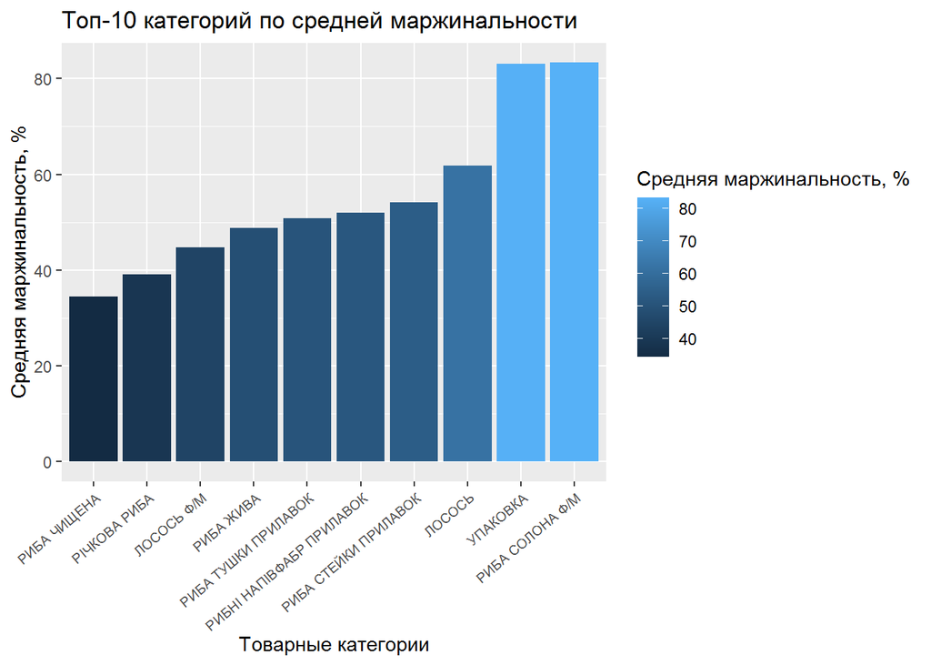

при оценке маржинальности используется показатель медианной маржи. Это делается с целью исключения влияния на результаты “выбросов” - значений, которые сильно отличаются от остальных в столбце (сильно больше или сильно меньше других). Здесь можно заметить, что “Рыба речная” находится на 9 месте, что подтверждает тот факт, что ее лидерство по товарообороту обеспечивается за счет высокой маржинальности. Также в этом рейтинге четвертое место занимает “Рыба стейки прилавок”, которая по товарообороту находится на 3 месте, а поколичеству продаж не входит в топ-10. Чтобы наверняка убедиться в предположении об обратной зависимости между маржинальностью категории и количеством продаж в ней, следует провести корреляционный тест:

```
##
##  Pearson's product-moment correlation
##
## data:  sales_dp_cor$`Средняя_маржа_%` and sales_dp_cor$Количество_продаж
## t = 0.59957, df = 101, p-value = 0.5501
## alternative hypothesis: true correlation is not equal to 0
## 95 percent confidence interval:
##  -0.1355328  0.2501950
## sample estimates:
##        cor
## 0.05955391
```

коэффициент корреляции равен 0.06, что говорит об отсутствии взаимосвязи между маржинальностью и количеством продаж, если учитывать все имеющиеся товарные категории. При этом для 10 наиболее маржинальных товарных категорий:

```
##
##  Pearson's product-moment correlation
##
## data:  sales_dp_cor$`Средняя_маржа_%` and sales_dp_cor$Количество_продаж
## t = -1.3266, df = 8, p-value = 0.2213
## alternative hypothesis: true correlation is not equal to 0
## 95 percent confidence interval:
##  -0.8318567  0.2797945
## sample estimates:
##        cor
## -0.4246387
```

коэффициент корреляции равен -0.42, что говорит о наличии, по крайней мере для топ-10 категорий, определенной обратной зависимости, которая, однако, не является сильной. Потому предположение об обратной зависимости между маржинальностью категори и количеством продаж в ней можно считать неподтвержденным.

### 2. Анализ продаж по периодам

Данные о продажах доступны по двум периодам: 01.01.19-31.08.19, 02.01.18-01.09.18.

| Период | Товарооборот_грн |
| --- | --- |
| 01.01.19-31.08.19 | 22785857 |
| 02.01.18-01.09.18 | 12322461 |

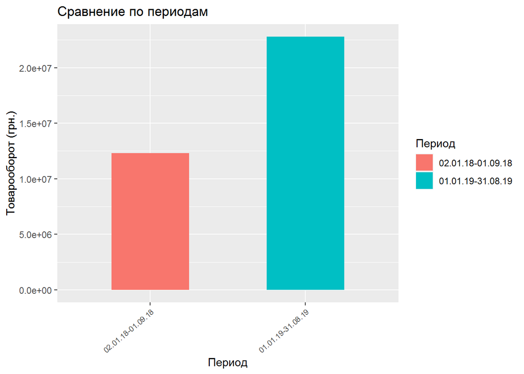

Прирост товарооборота составляет 85%, что говорит об увеличении покупательской способности клиентов. По имеющимся данным сложно определить, каковы предпосылки такого роста, но можно предположить, что позитивная динамика обеспечивается ростом доходов населения, эффективностью проводимой маркетинговой политики магазинов, улучшению организации выкладок товаров.

### 3. Анализ продаж по магазинам

| Магазин | Товарооборот_грн | Доля_рынка |
| --- | --- | --- |
| AUCHAN ZORYANYJ | 25153244 | 71.64 |
| WILLIAMSA | 3955251 | 11.27 |
| FROUNZE | 2576820 | 7.34 |
| PRAVDY | 2035629 | 5.80 |
| LEPSE | 1387374 | 3.95 |

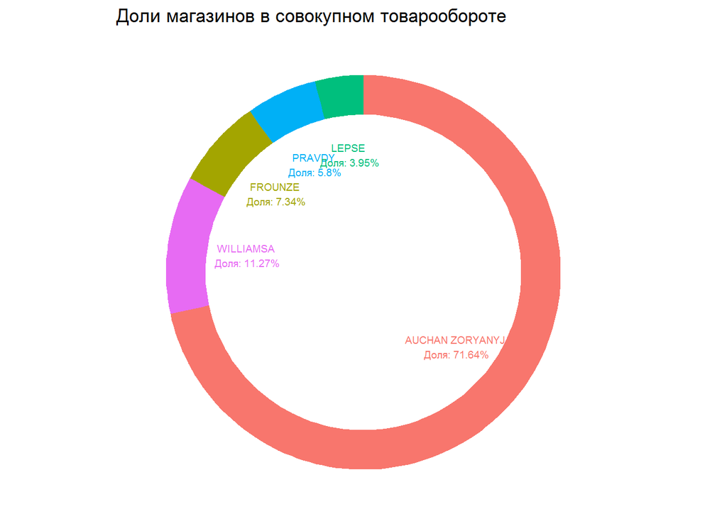

В разрезе магазинов наибольшую долю рынка (71.64%) имеет AUCHAN ZORYANYJ, то есть практически 3/4 товарооборота обеспечивается одним магазином из пяти представленных. Данный показатель может являться результатом наилучшего географического расположения магазина, эффективной организации торгового пространства, грамотной работы персонала.

### 4. Анализ продаж товарных категорий “Пельмени” и “Вареники”

Сравнение категорий

| Номенклатура | Товарооборот_грн | Доля_рынка | Количество_продаж | Средняя_маржа_% |
| --- | --- | --- | --- | --- |
| ПЕЛЬМЕНІ | 1137580.8 | 3.24 | 880 | 16.10 |
| ВАРЕНИКИ | 312328.9 | 0.89 | 370 | 16.39 |

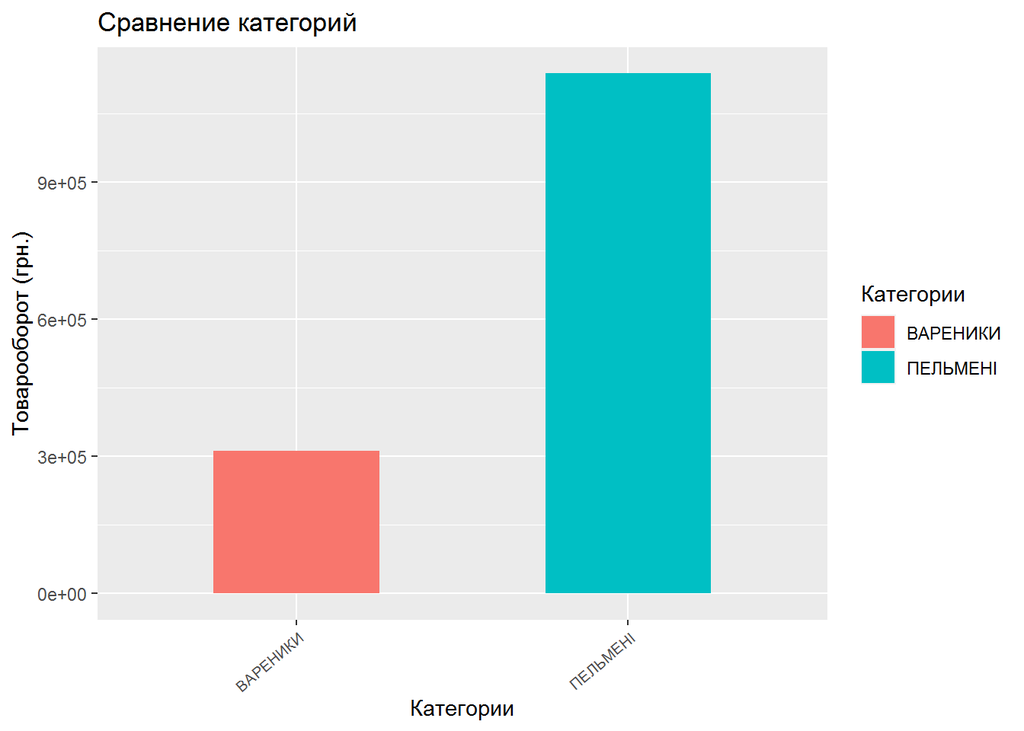

Пельмени занимают долю рынка в 3.24%. Это практически в 4 раза больше, чем доля рынка, занимаемая Варениками. Маржинальность данных категорий практически равна, поэтому нельзя сказать, что продажи Вареников значительно уступают продажам Пельменей за счет дороговизны первых. Здесь следует рассматривать, скорее, потребительские предпочтения.

Топ-10 товаров в категории Пельмени

| Номенклатура | Наименование | Товарооборот_грн | Доля_рынка |
| --- | --- | --- | --- |
| ПЕЛЬМЕНІ | ПЕЛЬМЕНІ"“ФІРМОВІ”"ЕКСК(Б/СОЇ)800 | 202059.55 | 0.58 |
| ПЕЛЬМЕНІ | П-НІ"“ВІД ШЕФА”"ФІРМОВІ 800Г | 115804.67 | 0.33 |
| ПЕЛЬМЕНІ | П-НІ "“МІШУТКА”" 600ГР | 106658.67 | 0.30 |
| ПЕЛЬМЕНІ | П-НІ ЛЕВАДА ФІРМОВІ, 1КГ | 68705.05 | 0.20 |
| ПЕЛЬМЕНІ | П-НІ "“МІШУТКА”" ТЕЛЯТИНА 400Г | 62572.63 | 0.18 |
| ПЕЛЬМЕНІ | П-НИ НЯМНЯМ КРУГЛ 0,4КГ | 43394.09 | 0.12 |
| ПЕЛЬМЕНІ | П-НИ ЛЕГКАСТР ПО-СИБІР 0,5КГ | 41571.67 | 0.12 |
| ПЕЛЬМЕНІ | ПЕЛЬМЕНІ СИБІРСЬКІ, 500Г | 39566.40 | 0.11 |
| ПЕЛЬМЕНІ | АШАН/ПЕЛЬМЕНІ СИБІРСЬКІ 800Г | 39025.92 | 0.11 |
| ПЕЛЬМЕНІ | АШАН/ПЕЛЬМЕНІ ФІРМОВІ 800Г | 36949.77 | 0.11 |

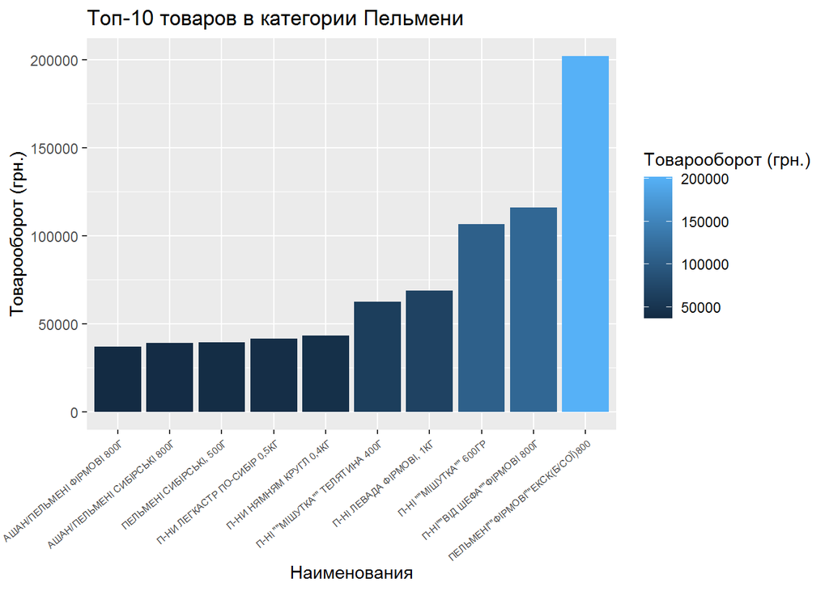

В категории Пельмени лидерство со значительным перевесом удерживают “Пельмени фирменные ЕКСК (Б/СОИ) 800”, практически в 2 раза опережая ближайшего конкурента. В целом в топ-10 по категории визуально явно выделяются 4 группы: к первой можно отнести лидера; 2-3 места образуют вторую группу; 4-5 места образуют третью группу; оставшиеся позиции с 6 по 10 образуют четвертую группу.

| Номенклатура | Наименование | Товарооборот_грн | Доля_рынка |
| --- | --- | --- | --- |
| ВАРЕНИКИ | ВАРЕНИКИ КАРТОПЛЯ ТА ГРИБЫ 0.8 | 84725.06 | 0.24 |
| ВАРЕНИКИ | ВАРЕНИКИ КАРТОПЛЯ 0.8 | 37357.05 | 0.11 |
| ВАРЕНИКИ | АШАН/ВАРЕНИКИ З КАРТ ГРИБ900Г | 23461.71 | 0.07 |
| ВАРЕНИКИ | ВАРЕНИКИ КАРТ.МАС ВІД ШЕФА | 21918.67 | 0.06 |
| ВАРЕНИКИ | АШАН/ВАРЕНИКИ З КАРТОП 900Г | 20206.77 | 0.06 |
| ВАРЕНИКИ | ВАРЕНИКИ КАРТ/ГРИБИ 900Г | 15916.10 | 0.05 |
| ВАРЕНИКИ | ВАР-КИ З КАПУСТОЮ 400ГР | 15225.79 | 0.04 |
| ВАРЕНИКИ | АШАН GB/ВАРЕНИКИ З КАПУСТОЮ350Г | 15212.73 | 0.04 |
| ВАРЕНИКИ | КД/ВАРЕНИКИ КАРТОП,ЦИБ350Г | 14896.39 | 0.04 |
| ВАРЕНИКИ | ВАРЕНИКИ З КАРТОПЛЕЮ 900Г | 11804.27 | 0.03 |

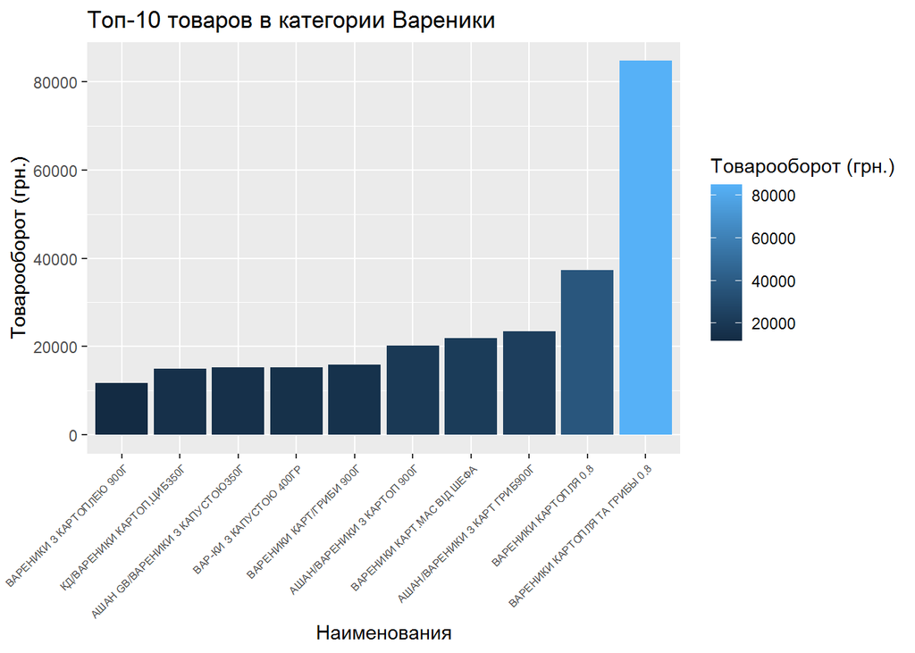

В категории Вареники все более однозначно. Лидер “Вареники картошка и грибы 0.8” более чем в 2 раза опережает ближайшего конкурента, позиции с 3 по 10 имеют небольшие разрывы в товарообороте между собой. Это говорит о потребительских предпочтениях в пользу, скорее, одной конкретной товарной позиции.

## Выводы

Суммируя все итоги, можно сделать краткие выводы по каждому вопросу:

1. Категория “Рыба речная” является явным фаворитом по товарообороту среди всех категорий. При этом по количеству продаж она занимает только 10 место из 10 лидеров по этому показателю. Ее лидерство в товарообороте обосновывается, по большей степени, высокой маржинальностью категории. При этом явная связь между количеством продаж и маржинальностью категорий не обнаружена.
2. За наблюдаемые периоды установлен практически двукратный рост товарооборота.
3. Наибольшую долю рынка среди всех магазинов имеет AUCHAN ZORYANYJ, что говорит о высокой эффективности работы данного магазина.
4. Категория “Вареники” сильно уступает категории “Пельмени”, что, в связи с приблизительно равным уровнем маржинальности в обеих категориях, вызвано, скорее, потребительскими предпочтениями.

По всем вопросам обращайтесь на почту tikhonmukha1998@gmail.com.